# Extensive Data Cleaning Example

Below you will see some extensive work in cleaning, imputing, and transforming data from a public flights dataset. You will find extensive insight into my actions, as well as see the process behind producing value-added insights for companies and clients alike.

```python
import pandas as pd
import numpy as np
from scipy import stats
from sklearn.utils import resample

import seaborn as sns
from seaborn_qqplot import pplot
import matplotlib.pylab as plt
```

```python
flights_df = pd.read_csv('assign_wk2/flights.csv')
```

```python
flights_df.head(10)
```

|  | YEAR | MONTH | DAY | DAY_OF_WEEK | AIRLINE | FLIGHT_NUMBER | TAIL_NUMBER | ORIGIN_AIRPORT | DESTINATION_AIRPORT | SCHEDULED_DEPARTURE | ... | ARRIVAL_TIME | ARRIVAL_DELAY | DIVERTED | CANCELLED | CANCELLATION_REASON | AIR_SYSTEM_DELAY | SECURITY_DELAY | AIRLINE_DELAY | LATE_AIRCRAFT_DELAY | WEATHER_DELAY |
| --- | --- | --- | --- | --- | --- | --- | --- | --- | --- | --- | --- | --- | --- | --- | --- | --- | --- | --- | --- | --- | --- |
| 0 | 2015 | 1 | 1 | 4 | AS | 98 | N407AS | ANC | SEA | 5 | ... | 408.0 | -22.0 | 0 | 0 | NaN | NaN | NaN | NaN | NaN | NaN |
| 1 | 2015 | 1 | 1 | 4 | AA | 2336 | N3KUAA | LAX | PBI | 10 | ... | 741.0 | -9.0 | 0 | 0 | NaN | NaN | NaN | NaN | NaN | NaN |
| 2 | 2015 | 1 | 1 | 4 | US | 840 | N171US | SFO | CLT | 20 | ... | 811.0 | 5.0 | 0 | 0 | NaN | NaN | NaN | NaN | NaN | NaN |
| 3 | 2015 | 1 | 1 | 4 | AA | 258 | N3HYAA | LAX | MIA | 20 | ... | 756.0 | -9.0 | 0 | 0 | NaN | NaN | NaN | NaN | NaN | NaN |
| 4 | 2015 | 1 | 1 | 4 | AS | 135 | N527AS | SEA | ANC | 25 | ... | 259.0 | -21.0 | 0 | 0 | NaN | NaN | NaN | NaN | NaN | NaN |
| 5 | 2015 | 1 | 1 | 4 | DL | 806 | N3730B | SFO | MSP | 25 | ... | 610.0 | 8.0 | 0 | 0 | NaN | NaN | NaN | NaN | NaN | NaN |
| 6 | 2015 | 1 | 1 | 4 | NK | 612 | N635NK | LAS | MSP | 25 | ... | 509.0 | -17.0 | 0 | 0 | NaN | NaN | NaN | NaN | NaN | NaN |
| 7 | 2015 | 1 | 1 | 4 | US | 2013 | N584UW | LAX | CLT | 30 | ... | 753.0 | -10.0 | 0 | 0 | NaN | NaN | NaN | NaN | NaN | NaN |
| 8 | 2015 | 1 | 1 | 4 | AA | 1112 | N3LAAA | SFO | DFW | 30 | ... | 532.0 | -13.0 | 0 | 0 | NaN | NaN | NaN | NaN | NaN | NaN |
| 9 | 2015 | 1 | 1 | 4 | DL | 1173 | N826DN | LAS | ATL | 30 | ... | 656.0 | -15.0 | 0 | 0 | NaN | NaN | NaN | NaN | NaN | NaN |

10 rows × 31 columns

```python
flights_df.tail(10)
```

|  | YEAR | MONTH | DAY | DAY_OF_WEEK | AIRLINE | FLIGHT_NUMBER | TAIL_NUMBER | ORIGIN_AIRPORT | DESTINATION_AIRPORT | SCHEDULED_DEPARTURE | ... | ARRIVAL_TIME | ARRIVAL_DELAY | DIVERTED | CANCELLED | CANCELLATION_REASON | AIR_SYSTEM_DELAY | SECURITY_DELAY | AIRLINE_DELAY | LATE_AIRCRAFT_DELAY | WEATHER_DELAY |
| --- | --- | --- | --- | --- | --- | --- | --- | --- | --- | --- | --- | --- | --- | --- | --- | --- | --- | --- | --- | --- | --- |
| 5819069 | 2015 | 12 | 31 | 4 | B6 | 1248 | N948JB | LAS | JFK | 2359 | ... | 1020.0 | 159.0 | 0 | 0 | NaN | 0.0 | 0.0 | 159.0 | 0.0 | 0.0 |
| 5819070 | 2015 | 12 | 31 | 4 | B6 | 80 | N584JB | RNO | JFK | 2359 | ... | 744.0 | -21.0 | 0 | 0 | NaN | NaN | NaN | NaN | NaN | NaN |
| 5819071 | 2015 | 12 | 31 | 4 | B6 | 802 | N589JB | SLC | MCO | 2359 | ... | 625.0 | 17.0 | 0 | 0 | NaN | 1.0 | 0.0 | 16.0 | 0.0 | 0.0 |
| 5819072 | 2015 | 12 | 31 | 4 | B6 | 98 | N607JB | DEN | JFK | 2359 | ... | 519.0 | -11.0 | 0 | 0 | NaN | NaN | NaN | NaN | NaN | NaN |
| 5819073 | 2015 | 12 | 31 | 4 | B6 | 66 | N655JB | ABQ | JFK | 2359 | ... | 549.0 | 3.0 | 0 | 0 | NaN | NaN | NaN | NaN | NaN | NaN |
| 5819074 | 2015 | 12 | 31 | 4 | B6 | 688 | N657JB | LAX | BOS | 2359 | ... | 753.0 | -26.0 | 0 | 0 | NaN | NaN | NaN | NaN | NaN | NaN |
| 5819075 | 2015 | 12 | 31 | 4 | B6 | 745 | N828JB | JFK | PSE | 2359 | ... | 430.0 | -16.0 | 0 | 0 | NaN | NaN | NaN | NaN | NaN | NaN |
| 5819076 | 2015 | 12 | 31 | 4 | B6 | 1503 | N913JB | JFK | SJU | 2359 | ... | 432.0 | -8.0 | 0 | 0 | NaN | NaN | NaN | NaN | NaN | NaN |
| 5819077 | 2015 | 12 | 31 | 4 | B6 | 333 | N527JB | MCO | SJU | 2359 | ... | 330.0 | -10.0 | 0 | 0 | NaN | NaN | NaN | NaN | NaN | NaN |
| 5819078 | 2015 | 12 | 31 | 4 | B6 | 839 | N534JB | JFK | BQN | 2359 | ... | 442.0 | 2.0 | 0 | 0 | NaN | NaN | NaN | NaN | NaN | NaN |

10 rows × 31 columns

```python
%matplotlib inline
```

```python
flights_df.info()
```

```
<class 'pandas.core.frame.DataFrame'>
RangeIndex: 5819079 entries, 0 to 5819078
Data columns (total 31 columns):
 #   Column               Dtype
---  ------               -----
 0   YEAR                 int64
 1   MONTH                int64
 2   DAY                  int64
 3   DAY_OF_WEEK          int64
 4   AIRLINE              object
 5   FLIGHT_NUMBER        int64
 6   TAIL_NUMBER          object
 7   ORIGIN_AIRPORT       object
 8   DESTINATION_AIRPORT  object
 9   SCHEDULED_DEPARTURE  int64
```

[output cut: 23 more lines]

```python
#grid = sns.FacetGrid(flights_df, row='ORIGIN_AIRPORT', col='DESTINATION_AIRPORT', height=2.2, aspect=1.6)
#grid.map(plt.hist, 'ARRIVAL_DELAY', bins=20)
#grid.add_legend()
```

```python
flights_df.isnull().sum()
```

```
YEAR                         0
MONTH                        0
DAY                          0
DAY_OF_WEEK                  0
AIRLINE                      0
FLIGHT_NUMBER                0
TAIL_NUMBER              14721
ORIGIN_AIRPORT               0
DESTINATION_AIRPORT          0
SCHEDULED_DEPARTURE          0
DEPARTURE_TIME           86153
DEPARTURE_DELAY          86153
TAXI_OUT                 89047
WHEELS_OFF               89047
SCHEDULED_TIME               6
ELAPSED_TIME            105071
AIR_TIME                105071
DISTANCE                     0
WHEELS_ON                92513
TAXI_IN                  92513
SCHEDULED_ARRIVAL            0
ARRIVAL_TIME             92513
ARRIVAL_DELAY           105071
DIVERTED                     0
CANCELLED                    0
CANCELLATION_REASON    5729195
AIR_SYSTEM_DELAY       4755640
SECURITY_DELAY         4755640
AIRLINE_DELAY          4755640
LATE_AIRCRAFT_DELAY    4755640
WEATHER_DELAY          4755640
dtype: int64
```

## Dropping Unnecessary Columns

Given that `Cancellation_Reason` is almost entirely blank, we will be dropping the column. My instincts want me to drop the 5 columns below it as well, but we were warned we may need them so we will hold off for now. While on the subject, I'm not sure that `TAIL_NUMBER` will be helping us, and there at first glance appears to be no way to impute these values, but for caution we will hold off for now.

```python
flights_df.drop(['CANCELLATION_REASON'],axis=1,inplace=True)
```

## Dropping More

While I was originally being cautious due to the warning, I now believe we should clean out our dataframe to only the columns that will be of use to us, so as to improve processing time and clarity in our summaries.

```python
remove = ['TAIL_NUMBER', 'AIR_SYSTEM_DELAY', 'SECURITY_DELAY', 'AIRLINE_DELAY', 'LATE_AIRCRAFT_DELAY', 'WEATHER_DELAY', 'WHEELS_ON',
         'TAXI_IN','DIVERTED', 'DAY', 'MONTH','YEAR','DAY_OF_WEEK', 'TAXI_OUT']
flights_df.drop(remove,axis=1,inplace=True)
```

```python
flights_df.head(10)
```

|  | AIRLINE | FLIGHT_NUMBER | ORIGIN_AIRPORT | DESTINATION_AIRPORT | SCHEDULED_DEPARTURE | DEPARTURE_TIME | DEPARTURE_DELAY | WHEELS_OFF | SCHEDULED_TIME | ELAPSED_TIME | AIR_TIME | DISTANCE | SCHEDULED_ARRIVAL | ARRIVAL_TIME | ARRIVAL_DELAY | CANCELLED |
| --- | --- | --- | --- | --- | --- | --- | --- | --- | --- | --- | --- | --- | --- | --- | --- | --- |
| 0 | AS | 98 | ANC | SEA | 5 | 2354.0 | -11.0 | 15.0 | 205.0 | 194.0 | 169.0 | 1448 | 430 | 408.0 | -22.0 | 0 |
| 1 | AA | 2336 | LAX | PBI | 10 | 2.0 | -8.0 | 14.0 | 280.0 | 279.0 | 263.0 | 2330 | 750 | 741.0 | -9.0 | 0 |
| 2 | US | 840 | SFO | CLT | 20 | 18.0 | -2.0 | 34.0 | 286.0 | 293.0 | 266.0 | 2296 | 806 | 811.0 | 5.0 | 0 |
| 3 | AA | 258 | LAX | MIA | 20 | 15.0 | -5.0 | 30.0 | 285.0 | 281.0 | 258.0 | 2342 | 805 | 756.0 | -9.0 | 0 |
| 4 | AS | 135 | SEA | ANC | 25 | 24.0 | -1.0 | 35.0 | 235.0 | 215.0 | 199.0 | 1448 | 320 | 259.0 | -21.0 | 0 |
| 5 | DL | 806 | SFO | MSP | 25 | 20.0 | -5.0 | 38.0 | 217.0 | 230.0 | 206.0 | 1589 | 602 | 610.0 | 8.0 | 0 |
| 6 | NK | 612 | LAS | MSP | 25 | 19.0 | -6.0 | 30.0 | 181.0 | 170.0 | 154.0 | 1299 | 526 | 509.0 | -17.0 | 0 |
| 7 | US | 2013 | LAX | CLT | 30 | 44.0 | 14.0 | 57.0 | 273.0 | 249.0 | 228.0 | 2125 | 803 | 753.0 | -10.0 | 0 |
| 8 | AA | 1112 | SFO | DFW | 30 | 19.0 | -11.0 | 36.0 | 195.0 | 193.0 | 173.0 | 1464 | 545 | 532.0 | -13.0 | 0 |
| 9 | DL | 1173 | LAS | ATL | 30 | 33.0 | 3.0 | 45.0 | 221.0 | 203.0 | 186.0 | 1747 | 711 | 656.0 | -15.0 | 0 |

```python
flights_df.tail(10)
```

|  | AIRLINE | FLIGHT_NUMBER | ORIGIN_AIRPORT | DESTINATION_AIRPORT | SCHEDULED_DEPARTURE | DEPARTURE_TIME | DEPARTURE_DELAY | WHEELS_OFF | SCHEDULED_TIME | ELAPSED_TIME | AIR_TIME | DISTANCE | SCHEDULED_ARRIVAL | ARRIVAL_TIME | ARRIVAL_DELAY | CANCELLED |
| --- | --- | --- | --- | --- | --- | --- | --- | --- | --- | --- | --- | --- | --- | --- | --- | --- |
| 5819069 | B6 | 1248 | LAS | JFK | 2359 | 238.0 | 159.0 | 312.0 | 282.0 | 282.0 | 243.0 | 2248 | 741 | 1020.0 | 159.0 | 0 |
| 5819070 | B6 | 80 | RNO | JFK | 2359 | 2359.0 | 0.0 | 11.0 | 306.0 | 285.0 | 268.0 | 2411 | 805 | 744.0 | -21.0 | 0 |
| 5819071 | B6 | 802 | SLC | MCO | 2359 | 15.0 | 16.0 | 29.0 | 249.0 | 250.0 | 211.0 | 1931 | 608 | 625.0 | 17.0 | 0 |
| 5819072 | B6 | 98 | DEN | JFK | 2359 | 6.0 | 7.0 | 19.0 | 211.0 | 193.0 | 173.0 | 1626 | 530 | 519.0 | -11.0 | 0 |
| 5819073 | B6 | 66 | ABQ | JFK | 2359 | 15.0 | 16.0 | 24.0 | 227.0 | 214.0 | 190.0 | 1826 | 546 | 549.0 | 3.0 | 0 |
| 5819074 | B6 | 688 | LAX | BOS | 2359 | 2355.0 | -4.0 | 17.0 | 320.0 | 298.0 | 272.0 | 2611 | 819 | 753.0 | -26.0 | 0 |
| 5819075 | B6 | 745 | JFK | PSE | 2359 | 2355.0 | -4.0 | 12.0 | 227.0 | 215.0 | 195.0 | 1617 | 446 | 430.0 | -16.0 | 0 |
| 5819076 | B6 | 1503 | JFK | SJU | 2359 | 2350.0 | -9.0 | 7.0 | 221.0 | 222.0 | 197.0 | 1598 | 440 | 432.0 | -8.0 | 0 |
| 5819077 | B6 | 333 | MCO | SJU | 2359 | 2353.0 | -6.0 | 3.0 | 161.0 | 157.0 | 144.0 | 1189 | 340 | 330.0 | -10.0 | 0 |
| 5819078 | B6 | 839 | JFK | BQN | 2359 | 14.0 | 15.0 | 28.0 | 221.0 | 208.0 | 189.0 | 1576 | 440 | 442.0 | 2.0 | 0 |

```python
flights_df.isnull().sum()
```

```
AIRLINE                     0
FLIGHT_NUMBER               0
ORIGIN_AIRPORT              0
DESTINATION_AIRPORT         0
SCHEDULED_DEPARTURE         0
DEPARTURE_TIME          86153
DEPARTURE_DELAY         86153
WHEELS_OFF              89047
SCHEDULED_TIME              6
ELAPSED_TIME           105071
AIR_TIME               105071
DISTANCE                    0
SCHEDULED_ARRIVAL           0
ARRIVAL_TIME            92513
ARRIVAL_DELAY          105071
CANCELLED                   0
dtype: int64
```

```python
flights_df.describe()
```

|  | FLIGHT_NUMBER | SCHEDULED_DEPARTURE | DEPARTURE_TIME | DEPARTURE_DELAY | WHEELS_OFF | SCHEDULED_TIME | ELAPSED_TIME | AIR_TIME | DISTANCE | SCHEDULED_ARRIVAL | ARRIVAL_TIME | ARRIVAL_DELAY | CANCELLED |
| --- | --- | --- | --- | --- | --- | --- | --- | --- | --- | --- | --- | --- | --- |
| count | 5.819079e+06 | 5.819079e+06 | 5.732926e+06 | 5.732926e+06 | 5.730032e+06 | 5.819073e+06 | 5.714008e+06 | 5.714008e+06 | 5.819079e+06 | 5.819079e+06 | 5.726566e+06 | 5.714008e+06 | 5.819079e+06 |
| mean | 2.173093e+03 | 1.329602e+03 | 1.335204e+03 | 9.370158e+00 | 1.357171e+03 | 1.416859e+02 | 1.370062e+02 | 1.135116e+02 | 8.223565e+02 | 1.493808e+03 | 1.476491e+03 | 4.407057e+00 | 1.544643e-02 |
| std | 1.757064e+03 | 4.837518e+02 | 4.964233e+02 | 3.708094e+01 | 4.980094e+02 | 7.521058e+01 | 7.421107e+01 | 7.223082e+01 | 6.077843e+02 | 5.071647e+02 | 5.263197e+02 | 3.927130e+01 | 1.233201e-01 |
| min | 1.000000e+00 | 1.000000e+00 | 1.000000e+00 | -8.200000e+01 | 1.000000e+00 | 1.800000e+01 | 1.400000e+01 | 7.000000e+00 | 2.100000e+01 | 1.000000e+00 | 1.000000e+00 | -8.700000e+01 | 0.000000e+00 |
| 25% | 7.300000e+02 | 9.170000e+02 | 9.210000e+02 | -5.000000e+00 | 9.350000e+02 | 8.500000e+01 | 8.200000e+01 | 6.000000e+01 | 3.730000e+02 | 1.110000e+03 | 1.059000e+03 | -1.300000e+01 | 0.000000e+00 |
| 50% | 1.690000e+03 | 1.325000e+03 | 1.330000e+03 | -2.000000e+00 | 1.343000e+03 | 1.230000e+02 | 1.180000e+02 | 9.400000e+01 | 6.470000e+02 | 1.520000e+03 | 1.512000e+03 | -5.000000e+00 | 0.000000e+00 |
| 75% | 3.230000e+03 | 1.730000e+03 | 1.740000e+03 | 7.000000e+00 | 1.754000e+03 | 1.730000e+02 | 1.680000e+02 | 1.440000e+02 | 1.062000e+03 | 1.918000e+03 | 1.917000e+03 | 8.000000e+00 | 0.000000e+00 |
| max | 9.855000e+03 | 2.359000e+03 | 2.400000e+03 | 1.988000e+03 | 2.400000e+03 | 7.180000e+02 | 7.660000e+02 | 6.900000e+02 | 4.983000e+03 | 2.400000e+03 | 2.400000e+03 | 1.971000e+03 | 1.000000e+00 |

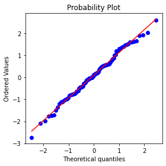

```python
fig, ax = plt.subplots(figsize=(4, 4))

norm_sample = stats.norm.rvs(size=100)
stats.probplot(norm_sample, plot=ax)

plt.tight_layout()
plt.show()
```

```python
print(pd.isnull(flights_df['ARRIVAL_DELAY']))
```

```
0          False
1          False
2          False
3          False
4          False
           ...
5819074    False
5819075    False
5819076    False
5819077    False
5819078    False
Name: ARRIVAL_DELAY, Length: 5819079, dtype: bool
```

```python
arrivals = pd.isnull(flights_df['ARRIVAL_DELAY'])

print(arrivals)
```

```
0          False
1          False
2          False
3          False
4          False
           ...
5819074    False
5819075    False
5819076    False
5819077    False
5819078    False
Name: ARRIVAL_DELAY, Length: 5819079, dtype: bool
```

```python
flights_df[arrivals]
```

|  | AIRLINE | FLIGHT_NUMBER | ORIGIN_AIRPORT | DESTINATION_AIRPORT | SCHEDULED_DEPARTURE | DEPARTURE_TIME | DEPARTURE_DELAY | WHEELS_OFF | SCHEDULED_TIME | ELAPSED_TIME | AIR_TIME | DISTANCE | SCHEDULED_ARRIVAL | ARRIVAL_TIME | ARRIVAL_DELAY | CANCELLED |
| --- | --- | --- | --- | --- | --- | --- | --- | --- | --- | --- | --- | --- | --- | --- | --- | --- |
| 32 | AS | 136 | ANC | SEA | 135 | NaN | NaN | NaN | 205.0 | NaN | NaN | 1448 | 600 | NaN | NaN | 1 |
| 42 | AA | 2459 | PHX | DFW | 200 | NaN | NaN | NaN | 120.0 | NaN | NaN | 868 | 500 | NaN | NaN | 1 |
| 68 | OO | 5254 | MAF | IAH | 510 | NaN | NaN | NaN | 87.0 | NaN | NaN | 429 | 637 | NaN | NaN | 1 |
| 82 | MQ | 2859 | SGF | DFW | 525 | NaN | NaN | NaN | 95.0 | NaN | NaN | 364 | 700 | NaN | NaN | 1 |
| 90 | OO | 5460 | RDD | SFO | 530 | NaN | NaN | NaN | 90.0 | NaN | NaN | 199 | 700 | NaN | NaN | 1 |
| ... | ... | ... | ... | ... | ... | ... | ... | ... | ... | ... | ... | ... | ... | ... | ... | ... |
| 5818157 | UA | 222 | SFO | LAX | 2000 | NaN | NaN | NaN | 96.0 | NaN | NaN | 337 | 2136 | NaN | NaN | 1 |
| 5818160 | WN | 5296 | MDW | ABQ | 2000 | 2013.0 | 13.0 | 2023.0 | 195.0 | NaN | NaN | 1121 | 2215 | 2325.0 | NaN | 0 |
| 5818318 | AA | 2245 | MIA | SAN | 2019 | NaN | NaN | NaN | 337.0 | NaN | NaN | 2267 | 2256 | NaN | NaN | 1 |
| 5818777 | NK | 416 | FLL | IAG | 2155 | NaN | NaN | NaN | 175.0 | NaN | NaN | 1176 | 50 | NaN | NaN | 1 |
| 5818843 | AA | 1042 | SAN | MIA | 2210 | NaN | NaN | NaN | 277.0 | NaN | NaN | 2267 | 547 | NaN | NaN | 1 |

105071 rows × 16 columns

## Imputing `ARRIVAL_DELAY`

```python
flights_df['CANCELLED'].nunique()
```

```
2
```

```python
flights_df['CANCELLED'].mean()
```

```
0.015446430612129514
```

```python
# 1.5% of flights were cancelled

flights_df.loc[flights_df['CANCELLED'] == 1]
```

|  | AIRLINE | FLIGHT_NUMBER | ORIGIN_AIRPORT | DESTINATION_AIRPORT | SCHEDULED_DEPARTURE | DEPARTURE_TIME | DEPARTURE_DELAY | WHEELS_OFF | SCHEDULED_TIME | ELAPSED_TIME | AIR_TIME | DISTANCE | SCHEDULED_ARRIVAL | ARRIVAL_TIME | ARRIVAL_DELAY | CANCELLED |
| --- | --- | --- | --- | --- | --- | --- | --- | --- | --- | --- | --- | --- | --- | --- | --- | --- |
| 32 | AS | 136 | ANC | SEA | 135 | NaN | NaN | NaN | 205.0 | NaN | NaN | 1448 | 600 | NaN | NaN | 1 |
| 42 | AA | 2459 | PHX | DFW | 200 | NaN | NaN | NaN | 120.0 | NaN | NaN | 868 | 500 | NaN | NaN | 1 |
| 68 | OO | 5254 | MAF | IAH | 510 | NaN | NaN | NaN | 87.0 | NaN | NaN | 429 | 637 | NaN | NaN | 1 |
| 82 | MQ | 2859 | SGF | DFW | 525 | NaN | NaN | NaN | 95.0 | NaN | NaN | 364 | 700 | NaN | NaN | 1 |
| 90 | OO | 5460 | RDD | SFO | 530 | NaN | NaN | NaN | 90.0 | NaN | NaN | 199 | 700 | NaN | NaN | 1 |
| ... | ... | ... | ... | ... | ... | ... | ... | ... | ... | ... | ... | ... | ... | ... | ... | ... |
| 5818090 | UA | 1789 | IAH | TPA | 1955 | NaN | NaN | NaN | 125.0 | NaN | NaN | 787 | 2300 | NaN | NaN | 1 |
| 5818157 | UA | 222 | SFO | LAX | 2000 | NaN | NaN | NaN | 96.0 | NaN | NaN | 337 | 2136 | NaN | NaN | 1 |
| 5818318 | AA | 2245 | MIA | SAN | 2019 | NaN | NaN | NaN | 337.0 | NaN | NaN | 2267 | 2256 | NaN | NaN | 1 |
| 5818777 | NK | 416 | FLL | IAG | 2155 | NaN | NaN | NaN | 175.0 | NaN | NaN | 1176 | 50 | NaN | NaN | 1 |
| 5818843 | AA | 1042 | SAN | MIA | 2210 | NaN | NaN | NaN | 277.0 | NaN | NaN | 2267 | 547 | NaN | NaN | 1 |

89884 rows × 16 columns

```python
flights_df.isnull().sum()
```

```
AIRLINE                     0
FLIGHT_NUMBER               0
ORIGIN_AIRPORT              0
DESTINATION_AIRPORT         0
SCHEDULED_DEPARTURE         0
DEPARTURE_TIME          86153
DEPARTURE_DELAY         86153
WHEELS_OFF              89047
SCHEDULED_TIME              6
ELAPSED_TIME           105071
AIR_TIME               105071
DISTANCE                    0
SCHEDULED_ARRIVAL           0
ARRIVAL_TIME            92513
ARRIVAL_DELAY          105071
CANCELLED                   0
dtype: int64
```

```python
flights_df.corr()
```

|  | FLIGHT_NUMBER | SCHEDULED_DEPARTURE | DEPARTURE_TIME | DEPARTURE_DELAY | WHEELS_OFF | SCHEDULED_TIME | ELAPSED_TIME | AIR_TIME | DISTANCE | SCHEDULED_ARRIVAL | ARRIVAL_TIME | ARRIVAL_DELAY | CANCELLED |
| --- | --- | --- | --- | --- | --- | --- | --- | --- | --- | --- | --- | --- | --- |
| FLIGHT_NUMBER | 1.000000 | -0.005485 | -0.001444 | -0.008665 | 0.005289 | -0.317394 | -0.306611 | -0.319681 | -0.331280 | -0.013947 | -0.002821 | 0.018419 | 0.037895 |
| SCHEDULED_DEPARTURE | -0.005485 | 1.000000 | 0.963791 | 0.110149 | 0.938008 | -0.016609 | -0.017935 | -0.015756 | -0.009572 | 0.706237 | 0.629342 | 0.100220 | 0.011752 |
| DEPARTURE_TIME | -0.001444 | 0.963791 | 1.000000 | 0.171723 | 0.971971 | -0.020851 | -0.021990 | -0.021146 | -0.016492 | 0.710223 | 0.648265 | 0.159787 | 0.008055 |
| DEPARTURE_DELAY | -0.008665 | 0.110149 | 0.171723 | 1.000000 | 0.162582 | 0.027799 | 0.030805 | 0.023495 | 0.024106 | 0.097566 | 0.049236 | 0.944672 | 0.033099 |
| WHEELS_OFF | 0.005289 | 0.938008 | 0.971971 | 0.162582 | 1.000000 | -0.028289 | -0.027133 | -0.029654 | -0.027586 | 0.721877 | 0.667991 | 0.155773 | 0.004805 |
| SCHEDULED_TIME | -0.317394 | -0.016609 | -0.020851 | 0.027799 | -0.028289 | 1.000000 | 0.985260 | 0.990749 | 0.984336 | 0.031963 | 0.020439 | -0.030029 | -0.027827 |
| ELAPSED_TIME | -0.306611 | -0.017935 | -0.021990 | 0.030805 | -0.027133 | 0.985260 | 1.000000 | 0.990033 | 0.973696 | 0.031246 | 0.022579 | 0.029120 | NaN |
| AIR_TIME | -0.319681 | -0.015756 | -0.021146 | 0.023495 | -0.029654 | 0.990749 | 0.990033 | 1.000000 | 0.985643 | 0.029698 | 0.019383 | -0.007108 | NaN |
| DISTANCE | -0.331280 | -0.009572 | -0.016492 | 0.024106 | -0.027586 | 0.984336 | 0.973696 | 0.985643 | 1.000000 | 0.027369 | 0.015098 | -0.025444 | -0.032853 |
| SCHEDULED_ARRIVAL | -0.013947 | 0.706237 | 0.710223 | 0.097566 | 0.721877 | 0.031963 | 0.031246 | 0.029698 | 0.027369 | 1.000000 | 0.861931 | 0.088824 | 0.007763 |
| ARRIVAL_TIME | -0.002821 | 0.629342 | 0.648265 | 0.049236 | 0.667991 | 0.020439 | 0.022579 | 0.019383 | 0.015098 | 0.861931 | 1.000000 | 0.049876 | NaN |
| ARRIVAL_DELAY | 0.018419 | 0.100220 | 0.159787 | 0.944672 | 0.155773 | -0.030029 | 0.029120 | -0.007108 | -0.025444 | 0.088824 | 0.049876 | 1.000000 | NaN |
| CANCELLED | 0.037895 | 0.011752 | 0.008055 | 0.033099 | 0.004805 | -0.027827 | NaN | NaN | -0.032853 | 0.007763 | NaN | NaN | 1.000000 |

## Let's gather our thoughts and build a plan

89884 Cancelled Flights, but only 86153 rows of `DEPARTURE_TIME` and `DEPARTURE_DELAY` NaN values. We will now be removing all of our Cancelled Flights, as those are all flights that never took off, and we want to look at Delays. You will see me struggle some below, but ultimately make a copy of the df just to be safe in practicing my conditional removal of rows based on Cancellation.

```python
#flights_df.loc[(flights_df['CANCELLED'] == 1) & (flights_df['DEPARTURE_TIME'] != null)]
```

```python
flights_df['AIRLINE'].nunique()
```

```
14
```

```python
airlines_df = pd.read_csv('assign_wk2/airlines.csv')
```

```python
airlines_df
```

|  | IATA_CODE | AIRLINE |
| --- | --- | --- |
| 0 | UA | United Air Lines Inc. |
| 1 | AA | American Airlines Inc. |
| 2 | US | US Airways Inc. |
| 3 | F9 | Frontier Airlines Inc. |
| 4 | B6 | JetBlue Airways |
| 5 | OO | Skywest Airlines Inc. |
| 6 | AS | Alaska Airlines Inc. |
| 7 | NK | Spirit Air Lines |
| 8 | WN | Southwest Airlines Co. |
| 9 | DL | Delta Air Lines Inc. |
| 10 | EV | Atlantic Southeast Airlines |
| 11 | HA | Hawaiian Airlines Inc. |
| 12 | MQ | American Eagle Airlines Inc. |
| 13 | VX | Virgin America |

```python
airlines = [airlines_df['AIRLINE']]
```

```python
type(airlines)
```

```
list
```

```python
print(airlines)
```

```
[0            United Air Lines Inc.
1           American Airlines Inc.
2                  US Airways Inc.
3           Frontier Airlines Inc.
4                  JetBlue Airways
5            Skywest Airlines Inc.
6             Alaska Airlines Inc.
7                 Spirit Air Lines
8           Southwest Airlines Co.
9             Delta Air Lines Inc.
10     Atlantic Southeast Airlines
11          Hawaiian Airlines Inc.
12    American Eagle Airlines Inc.
13                  Virgin America
Name: AIRLINE, dtype: object]
```

```python
flights_df_copy = flights_df.copy()
```

```python
flights_df_copy.describe()
```

|  | FLIGHT_NUMBER | SCHEDULED_DEPARTURE | DEPARTURE_TIME | DEPARTURE_DELAY | WHEELS_OFF | SCHEDULED_TIME | ELAPSED_TIME | AIR_TIME | DISTANCE | SCHEDULED_ARRIVAL | ARRIVAL_TIME | ARRIVAL_DELAY | CANCELLED |
| --- | --- | --- | --- | --- | --- | --- | --- | --- | --- | --- | --- | --- | --- |
| count | 5.819079e+06 | 5.819079e+06 | 5.732926e+06 | 5.732926e+06 | 5.730032e+06 | 5.819073e+06 | 5.714008e+06 | 5.714008e+06 | 5.819079e+06 | 5.819079e+06 | 5.726566e+06 | 5.714008e+06 | 5.819079e+06 |
| mean | 2.173093e+03 | 1.329602e+03 | 1.335204e+03 | 9.370158e+00 | 1.357171e+03 | 1.416859e+02 | 1.370062e+02 | 1.135116e+02 | 8.223565e+02 | 1.493808e+03 | 1.476491e+03 | 4.407057e+00 | 1.544643e-02 |
| std | 1.757064e+03 | 4.837518e+02 | 4.964233e+02 | 3.708094e+01 | 4.980094e+02 | 7.521058e+01 | 7.421107e+01 | 7.223082e+01 | 6.077843e+02 | 5.071647e+02 | 5.263197e+02 | 3.927130e+01 | 1.233201e-01 |
| min | 1.000000e+00 | 1.000000e+00 | 1.000000e+00 | -8.200000e+01 | 1.000000e+00 | 1.800000e+01 | 1.400000e+01 | 7.000000e+00 | 2.100000e+01 | 1.000000e+00 | 1.000000e+00 | -8.700000e+01 | 0.000000e+00 |
| 25% | 7.300000e+02 | 9.170000e+02 | 9.210000e+02 | -5.000000e+00 | 9.350000e+02 | 8.500000e+01 | 8.200000e+01 | 6.000000e+01 | 3.730000e+02 | 1.110000e+03 | 1.059000e+03 | -1.300000e+01 | 0.000000e+00 |
| 50% | 1.690000e+03 | 1.325000e+03 | 1.330000e+03 | -2.000000e+00 | 1.343000e+03 | 1.230000e+02 | 1.180000e+02 | 9.400000e+01 | 6.470000e+02 | 1.520000e+03 | 1.512000e+03 | -5.000000e+00 | 0.000000e+00 |
| 75% | 3.230000e+03 | 1.730000e+03 | 1.740000e+03 | 7.000000e+00 | 1.754000e+03 | 1.730000e+02 | 1.680000e+02 | 1.440000e+02 | 1.062000e+03 | 1.918000e+03 | 1.917000e+03 | 8.000000e+00 | 0.000000e+00 |
| max | 9.855000e+03 | 2.359000e+03 | 2.400000e+03 | 1.988000e+03 | 2.400000e+03 | 7.180000e+02 | 7.660000e+02 | 6.900000e+02 | 4.983000e+03 | 2.400000e+03 | 2.400000e+03 | 1.971000e+03 | 1.000000e+00 |

```python
flights_df_copy.head()
```

|  | AIRLINE | FLIGHT_NUMBER | ORIGIN_AIRPORT | DESTINATION_AIRPORT | SCHEDULED_DEPARTURE | DEPARTURE_TIME | DEPARTURE_DELAY | WHEELS_OFF | SCHEDULED_TIME | ELAPSED_TIME | AIR_TIME | DISTANCE | SCHEDULED_ARRIVAL | ARRIVAL_TIME | ARRIVAL_DELAY | CANCELLED |
| --- | --- | --- | --- | --- | --- | --- | --- | --- | --- | --- | --- | --- | --- | --- | --- | --- |
| 0 | AS | 98 | ANC | SEA | 5 | 2354.0 | -11.0 | 15.0 | 205.0 | 194.0 | 169.0 | 1448 | 430 | 408.0 | -22.0 | 0 |
| 1 | AA | 2336 | LAX | PBI | 10 | 2.0 | -8.0 | 14.0 | 280.0 | 279.0 | 263.0 | 2330 | 750 | 741.0 | -9.0 | 0 |
| 2 | US | 840 | SFO | CLT | 20 | 18.0 | -2.0 | 34.0 | 286.0 | 293.0 | 266.0 | 2296 | 806 | 811.0 | 5.0 | 0 |
| 3 | AA | 258 | LAX | MIA | 20 | 15.0 | -5.0 | 30.0 | 285.0 | 281.0 | 258.0 | 2342 | 805 | 756.0 | -9.0 | 0 |
| 4 | AS | 135 | SEA | ANC | 25 | 24.0 | -1.0 | 35.0 | 235.0 | 215.0 | 199.0 | 1448 | 320 | 259.0 | -21.0 | 0 |

```python
is_cancelled = flights_df_copy[flights_df_copy['CANCELLED'] == 1].index
```

```python
flights_df_copy.drop(is_cancelled, inplace = True)
```

```python
flights_df_copy.isnull().sum()
```

```
AIRLINE                    0
FLIGHT_NUMBER              0
ORIGIN_AIRPORT             0
DESTINATION_AIRPORT        0
SCHEDULED_DEPARTURE        0
DEPARTURE_TIME             0
DEPARTURE_DELAY            0
WHEELS_OFF                 0
SCHEDULED_TIME             1
ELAPSED_TIME           15187
AIR_TIME               15187
DISTANCE                   0
SCHEDULED_ARRIVAL          0
ARRIVAL_TIME            2629
ARRIVAL_DELAY          15187
CANCELLED                  0
dtype: int64
```

## Begin imputing our data now that the cancelled flights, which simply couldn't have been imputed accurately, are out of the way.

Quickly, what is the 1 null value left for Scheduled_time? Pretty weird, lets look

```python
flights_df_copy[flights_df_copy['SCHEDULED_TIME'].isnull() == True]
```

|  | AIRLINE | FLIGHT_NUMBER | ORIGIN_AIRPORT | DESTINATION_AIRPORT | SCHEDULED_DEPARTURE | DEPARTURE_TIME | DEPARTURE_DELAY | WHEELS_OFF | SCHEDULED_TIME | ELAPSED_TIME | AIR_TIME | DISTANCE | SCHEDULED_ARRIVAL | ARRIVAL_TIME | ARRIVAL_DELAY | CANCELLED |
| --- | --- | --- | --- | --- | --- | --- | --- | --- | --- | --- | --- | --- | --- | --- | --- | --- |
| 1720237 | NK | 174 | FLL | LGA | 1602 | 1857.0 | 175.0 | 1921.0 | NaN | NaN | NaN | 1076 | 1900 | NaN | NaN | 0 |

It looks like, for some reason, our arrival time was never recorded. We will drop this record, as it is unworkable with such missing information.

```python
scheduled_drop = flights_df_copy[flights_df_copy['SCHEDULED_TIME'].isnull() == True].index
```

```python
flights_df_copy.drop(scheduled_drop, inplace = True)
```

```python
flights_df_copy.isnull().sum()
```

```
AIRLINE                    0
FLIGHT_NUMBER              0
ORIGIN_AIRPORT             0
DESTINATION_AIRPORT        0
SCHEDULED_DEPARTURE        0
DEPARTURE_TIME             0
DEPARTURE_DELAY            0
WHEELS_OFF                 0
SCHEDULED_TIME             0
ELAPSED_TIME           15186
AIR_TIME               15186
DISTANCE                   0
SCHEDULED_ARRIVAL          0
ARRIVAL_TIME            2628
ARRIVAL_DELAY          15186
CANCELLED                  0
dtype: int64
```

Now, our plan is to impute our arrival_delays based on arrival_time and scheduled_arrival. Without arrival_time, and given that anywhere arrival_time is null, so is air_time and elapsed_time, we will have to also drop arrival_time's null values, then finally impute.

```python
time_drop = flights_df_copy[flights_df_copy['ARRIVAL_TIME'].isnull() == True].index
```

```python
flights_df_copy.drop(time_drop, inplace = True)
```

```python
flights_df_copy.isnull().sum()
```

```
AIRLINE                    0
FLIGHT_NUMBER              0
ORIGIN_AIRPORT             0
DESTINATION_AIRPORT        0
SCHEDULED_DEPARTURE        0
DEPARTURE_TIME             0
DEPARTURE_DELAY            0
WHEELS_OFF                 0
SCHEDULED_TIME             0
ELAPSED_TIME           12558
AIR_TIME               12558
DISTANCE                   0
SCHEDULED_ARRIVAL          0
ARRIVAL_TIME               0
ARRIVAL_DELAY          12558
CANCELLED                  0
dtype: int64
```

```python
#reg_drop = flights_df_copy[flights_df_copy['ORIGIN_AIRPORT'] > 0].index
```

### Huzzah! We finally have enough data to begin imputing our missing values, then getting to the analysis!

```python
missing_delays = []

delay_is_true = flights_df_copy[flights_df_copy['ARRIVAL_DELAY'].isnull() == True].index
```

```python
def clean_nulls(value):
    if pd.isnull(value):
        value = flights_df_copy['ARRIVAL_TIME'] - flights_df_copy['SCHEDULED_ARRIVAL']
```

```python
flights_df_copy['ARRIVAL_TIME'].apply(clean_nulls)
```

```
0          None
1          None
2          None
3          None
4          None
           ...
5819074    None
5819075    None
5819076    None
5819077    None
5819078    None
Name: ARRIVAL_TIME, Length: 5726566, dtype: object
```

```python
flights_df_copy.head()
```

|  | AIRLINE | FLIGHT_NUMBER | ORIGIN_AIRPORT | DESTINATION_AIRPORT | SCHEDULED_DEPARTURE | DEPARTURE_TIME | DEPARTURE_DELAY | WHEELS_OFF | SCHEDULED_TIME | ELAPSED_TIME | AIR_TIME | DISTANCE | SCHEDULED_ARRIVAL | ARRIVAL_TIME | ARRIVAL_DELAY | CANCELLED |
| --- | --- | --- | --- | --- | --- | --- | --- | --- | --- | --- | --- | --- | --- | --- | --- | --- |
| 0 | AS | 98 | ANC | SEA | 5 | 2354.0 | -11.0 | 15.0 | 205.0 | 194.0 | 169.0 | 1448 | 430 | 408.0 | -22.0 | 0 |
| 1 | AA | 2336 | LAX | PBI | 10 | 2.0 | -8.0 | 14.0 | 280.0 | 279.0 | 263.0 | 2330 | 750 | 741.0 | -9.0 | 0 |
| 2 | US | 840 | SFO | CLT | 20 | 18.0 | -2.0 | 34.0 | 286.0 | 293.0 | 266.0 | 2296 | 806 | 811.0 | 5.0 | 0 |
| 3 | AA | 258 | LAX | MIA | 20 | 15.0 | -5.0 | 30.0 | 285.0 | 281.0 | 258.0 | 2342 | 805 | 756.0 | -9.0 | 0 |
| 4 | AS | 135 | SEA | ANC | 25 | 24.0 | -1.0 | 35.0 | 235.0 | 215.0 | 199.0 | 1448 | 320 | 259.0 | -21.0 | 0 |

```python
flights_df_copy.isnull().sum()
```

```
AIRLINE                    0
FLIGHT_NUMBER              0
ORIGIN_AIRPORT             0
DESTINATION_AIRPORT        0
SCHEDULED_DEPARTURE        0
DEPARTURE_TIME             0
DEPARTURE_DELAY            0
WHEELS_OFF                 0
SCHEDULED_TIME             0
ELAPSED_TIME           12558
AIR_TIME               12558
DISTANCE                   0
SCHEDULED_ARRIVAL          0
ARRIVAL_TIME               0
ARRIVAL_DELAY          12558
CANCELLED                  0
dtype: int64
```

```python
flights_df_copy['NEW_ARRIVAL_DELAY_FULL'] = flights_df_copy['ARRIVAL_TIME'] - flights_df_copy['SCHEDULED_ARRIVAL']
```

```python
flights_df_copy.head()
```

|  | AIRLINE | FLIGHT_NUMBER | ORIGIN_AIRPORT | DESTINATION_AIRPORT | SCHEDULED_DEPARTURE | DEPARTURE_TIME | DEPARTURE_DELAY | WHEELS_OFF | SCHEDULED_TIME | ELAPSED_TIME | AIR_TIME | DISTANCE | SCHEDULED_ARRIVAL | ARRIVAL_TIME | ARRIVAL_DELAY | CANCELLED | NEW_ARRIVAL_DELAY_FULL |
| --- | --- | --- | --- | --- | --- | --- | --- | --- | --- | --- | --- | --- | --- | --- | --- | --- | --- |
| 0 | AS | 98 | ANC | SEA | 5 | 2354.0 | -11.0 | 15.0 | 205.0 | 194.0 | 169.0 | 1448 | 430 | 408.0 | -22.0 | 0 | -22.0 |
| 1 | AA | 2336 | LAX | PBI | 10 | 2.0 | -8.0 | 14.0 | 280.0 | 279.0 | 263.0 | 2330 | 750 | 741.0 | -9.0 | 0 | -9.0 |
| 2 | US | 840 | SFO | CLT | 20 | 18.0 | -2.0 | 34.0 | 286.0 | 293.0 | 266.0 | 2296 | 806 | 811.0 | 5.0 | 0 | 5.0 |
| 3 | AA | 258 | LAX | MIA | 20 | 15.0 | -5.0 | 30.0 | 285.0 | 281.0 | 258.0 | 2342 | 805 | 756.0 | -9.0 | 0 | -49.0 |
| 4 | AS | 135 | SEA | ANC | 25 | 24.0 | -1.0 | 35.0 | 235.0 | 215.0 | 199.0 | 1448 | 320 | 259.0 | -21.0 | 0 | -61.0 |

```python
flights_df_copy.isnull().sum()
```

```
AIRLINE                       0
FLIGHT_NUMBER                 0
ORIGIN_AIRPORT                0
DESTINATION_AIRPORT           0
SCHEDULED_DEPARTURE           0
DEPARTURE_TIME                0
DEPARTURE_DELAY               0
WHEELS_OFF                    0
SCHEDULED_TIME                0
ELAPSED_TIME              12558
AIR_TIME                  12558
DISTANCE                      0
SCHEDULED_ARRIVAL             0
ARRIVAL_TIME                  0
ARRIVAL_DELAY             12558
CANCELLED                     0
NEW_ARRIVAL_DELAY_FULL        0
dtype: int64
```

```python
flights_df_copy.drop(['ARRIVAL_DELAY'], axis=1,inplace=True)
```

After some overcomplication and a guide to the easy call of a new column to make our new arrival delay column from our professor, I am now at a palce where I can drop my last null values. These are only 12558 values in a massive data set, and there is no way to accurately impute them. They also won't be necessary for our delay analysis, so with that said we will be dropping them and getting to our analysis.

NOTE it is important that we didn't just drop the rows for the null values provided from elapsed and air time, as we can see they were also our missing delays; we are simply dropping the elapsed time and air time columns, as they provide nothing to the analysis we will be performing.

```python
flights_df_copy.drop(['ELAPSED_TIME', 'AIR_TIME'], axis=1,inplace=True)
```

### Small Cheer

```python
flights_df_copy.isnull().sum()
```

```
AIRLINE                   0
FLIGHT_NUMBER             0
ORIGIN_AIRPORT            0
DESTINATION_AIRPORT       0
SCHEDULED_DEPARTURE       0
DEPARTURE_TIME            0
DEPARTURE_DELAY           0
WHEELS_OFF                0
SCHEDULED_TIME            0
DISTANCE                  0
SCHEDULED_ARRIVAL         0
ARRIVAL_TIME              0
CANCELLED                 0
NEW_ARRIVAL_DELAY_FULL    0
dtype: int64
```

```python
regional_airports = ['14747', '14771',
       '12889', '12892', '14869', '10299', '11292', '14107', '11630',
       '10732', '14254', '10141', '10627', '11982', '12173', '13930',
       '14683', '12266', '11618', '10721', '13487', '11884', '15919',
       '13851', '11111', '10693', '12191', '14783', '15016', '14487',
       '10423', '15370', '11953', '13891', '15376', '11778', '11278',
       '14100', '13204', '15304', '11637', '14842', '10155', '11775',
       '11298', '11057', '13931', '10821', '14122', '11049', '10990',
       '10631', '13158', '14108', '13198', '11447', '12206', '13495',
       '14057', '15624', '10747', '15411', '12891', '10994', '13256',
       '10792', '14492', '12451', '13127', '10781', '14960', '12278',
       '14685', '11995', '13485', '11977', '10257', '13796', '13232',
       '13296', '14570', '14893', '14524', '12217', '10713', '10208',
       '10136', '11603', '14689', '11471', '11315', '13264', '12478',
       '14814', '11308', '11066', '12896', '10397', '14307', '11721',
       '11140', '10185', '13277', '11203', '13342', '11433', '11697',
       '12953', '10599', '12156', '14952', '10620', '11042', '15096',
       '10408', '15249', '11423', '12915', '12264', '12339', '10140',
       '13871', '14027', '13244', '11267', '11540', '14576', '10868',
       '13486', '13476', '14489', '12945', '15607', '10529', '11986',
       '14635', '13303', '10785', '15380', '11996', '10561', '10874',
       '13367', '10146', '10431', '11973', '10980', '12197', '14098',
       '12323', '10577', '11150', '10135', '11617', '13795', '13029',
       '11003', '11146', '11577', '15356', '11259', '10279', '14321',
       '14843', '11638', '14828', '11481', '12951', '10434', '12448',
       '14730', '15323', '14252', '11193', '10849', '14193', '14986',
       '11641', '12992', '13422', '11612', '11823', '11980', '13290',
       '10158', '10685', '13377', '11109', '11076', '11122', '11865',
       '14543', '14905', '11587', '14457', '12335', '12343', '12003',
       '10157', '12884', '14633', '15048', '10268', '15295', '12389',
       '11525', '14262', '12888', '12391', '11648', '14696', '12758',
       '13830', '10469', '15412', '10731', '14679', '14831', '11413',
       '13433', '12982', '11867', '14698', '11537', '15389', '12402',
       '11337', '13360', '13076', '14006', '10728', '15401', '13230',
       '12016', '11067', '11274', '11921', '12519', '11013', '10779',
       '14150', '14794', '12511', '12177', '12523', '14908', '12007',
       '14588', '13577', '13061', '15041', '14109', '10800', '12954',
       '12441', '12898', '16218', '14113', '11624', '11503', '10739',
       '14574', '14711', '12129', '15070', '14520', '13184', '11252',
       '12280', '13241', '11898', '15024', '14674', '10551', '12819',
       '13459', '10581', '13970', '10372', '10918', '14709', '12255',
       11267, 12266, 10821, 14771, 11433, 11982, 11905, 15411, 14679,
       14108, 10397, 13871, 11618, 14574, 10423, 11259, 11140, 12191,
       12889, 13198, 10529, 10693, 13232, 11540, 14570, 14635, 14831,
       11298, 13204, 11278, 14100, 12892, 12478, 13930, 15304, 14107,
       12523, 12954, 11697, 14057, 12339, 13487, 14893, 11986, 11292,
       14576, 15370, 12402, 14908, 12953, 12758, 15016, 10721, 12264,
       10685, 11612, 13277, 11057, 12891, 12197, 11193, 10800, 13495,
       13891, 13244, 14843, 14747, 11996, 10333, 14262, 11695, 13342,
       14698, 10431, 15376, 12451, 14524, 13830, 13796, 14122, 14960,
       16218, 10713, 11066, 10208, 14683, 14869, 14492, 11638, 11413,
       10792, 10408, 14689, 10980, 14952, 12951, 15323, 11884, 14307,
       14730, 14783, 11603, 11977, 11921, 13577, 13061, 13851, 11042,
       12448, 12992, 10874, 12896, 11308, 12173, 12206, 13377, 10747,
       13256, 13303, 10185, 10599, 10140, 15295, 11898, 13795, 10728,
       10994, 12391, 10299, 12217, 13290, 12007, 11109, 15096, 10627,
       13433, 15249, 12278, 12915, 11637, 13931, 13485, 11721, 11775,
       13476, 15841, 14027, 15380, 12945, 11315, 15919, 13360, 10868,
       14986, 12982, 10279, 11150, 13264, 14193, 11823, 13367, 10469,
       11423, 11337, 11252, 13029, 14696, 11049, 13296, 14685, 13158,
       12323, 10257, 14588, 11274, 13344, 13933, 15412, 13422, 11146,
       15991, 13230, 14794, 11003, 14828, 10781, 10990, 10785, 10434,
       14457, 11481, 11537, 10136, 14814, 10754, 10135, 10731, 13127,
       14321, 10849, 14098, 10146, 15607, 11624, 12177, 10158, 12884,
       15624, 14256, 11973, 14842, 15356, 10561, 14113, 15389, 14489,
       12094, 12888, 13076, 12129, 13873, 10157, 11995, 10631, 12441,
       12343, 14252, 11097, 10732, 10154, 11122, 11641, 13486, 12003,
       10620, 10779, 12335, 11076, 15041, 12156, 12280, 10926, 12819,
       11865, 12519, 11778, 10551, 12389, 11953, 12898, 15024, 10155,
       11013, 10372, 11587, 13964, 11980, 11630, 11648, 14905, 11525,
       15070, 11471, 11111, 14633, 11447, 11203, 13241, 12511, 11067,
       10268, 13184, 10141, 13541, 14150, 15027, 14109, 15048, 14006,
       10739, 14520, 11617, 14487, 11867, 14674, 14543, 10577, 10170,
       11577, 14709, 14711, 12255, 10165, 10918, 15401, 15497, 12265,
       14254, 10581, 12016, 11503, 13459, 13970, 14222, 14025, 13502,
       '15841', '13344', '15991', '10754', '14256', '13873', '11097',
       '10926', '11695', '11905', '15027', '13933', '10170', '10333',
       '14222', '14025', '13502', '15497', '12265']
```

```python
#grid = sns.FacetGrid(flights_df_copy, row='ORIGIN_AIRPORT', height=3, aspect=3)
#grip.map_dataframe(sns.histplot, x='NEW_ARRIVAL_DELAY_FULL')
```

```python
origin_airports = [flights_df_copy['ORIGIN_AIRPORT']]
arrival_delays = [flights_df_copy['NEW_ARRIVAL_DELAY_FULL']]
```

```python
print(origin_airports)
```

```
[0          ANC
1          LAX
2          SFO
3          LAX
4          SEA
          ...
5819074    LAX
5819075    JFK
5819076    JFK
5819077    MCO
5819078    JFK
Name: ORIGIN_AIRPORT, Length: 5726566, dtype: object]
```

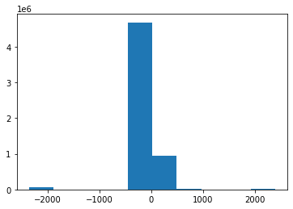

```python
plt.hist(flights_df_copy.NEW_ARRIVAL_DELAY_FULL)
```

```python
flights_df_copy['ORIGIN_AIRPORT'].unique()
```

```
array(['ANC', 'LAX', 'SFO', 'SEA', 'LAS', 'DEN', 'SLC', 'PDX', 'FAI',
       'MSP', 'PHX', 'SJU', 'PBG', 'IAG', 'PSE', 'BQN', 'ORD', 'GEG',
       'HNL', 'ONT', 'MCO', 'BOS', 'HIB', 'ABR', 'DFW', 'MKE', 'IAH',
       'BNA', 'BRO', 'VPS', 'BOI', 'BJI', 'PHL', 'SBN', 'EUG', 'IAD',
       'BUF', 'PWM', 'JFK', 'CRP', 'PIA', 'FAT', 'SMF', 'AUS', 'MCI',
       'ATL', 'JAX', 'MFR', 'IDA', 'MSN', 'DCA', 'SAT', 'CHS', 'SBA',
       'IND', 'CLE', 'GSP', 'BDL', 'RIC', 'BFL', 'OMA', 'RDM', 'FLL',
       'CID', 'TPA', 'SYR', 'ROC', 'TYR', 'LAN', 'GSO', 'EWR', 'PBI',
       'RSW', 'OAK', 'PVD', 'RNO', 'PIT', 'ABQ', 'MIA', 'BWI', 'TUL',
       'LGA', 'LIT', 'MSY', 'OKC', 'ATW', 'PNS', 'MEM', 'TYS', 'MHT',
       'SAV', 'CLT', 'GRB', 'ABE', 'JAN', 'OAJ', 'FAR', 'ERI', 'LEX',
       'CWA', 'TTN', 'RDU', 'CVG', 'BHM', 'ACY', 'DTW', 'RAP', 'TUS',
       'EAU', 'DLH', 'FSD', 'INL', 'SPI', 'CLD', 'COD', 'CMH', 'PSC',
       'CPR', 'ACV', 'DAL', 'PAH', 'MRY', 'ESC', 'ISN', 'PSP', 'CAE',
       'STL', 'BTV', 'MTJ', 'GCC', 'OGG', 'SJC', 'GUC', 'ORF', 'MOT',
       'MLU', 'KOA', 'HOU', 'MOB', 'SAN', 'LAW', 'PIB', 'MGM', 'SBP',
       'COS', 'LAR', 'DRO', 'BIS', 'ITO', 'BTR', 'HLN', 'BZN', 'MDW',
       'MDT', 'SCE', 'LIH', 'TWF', 'BPT', 'GPT', 'STC', 'HPN', 'MLB',
       'PLN', 'CIU', 'CAK', 'DSM', 'BLI', 'SHV', 'SNA', 'ALB', 'LNK',
       'CMI', 'GTF', 'EKO', 'LGB', 'AVL', 'HSV', 'XNA', 'SUX', 'HYS',
       'MFE', 'ISP', 'BUR', 'DAB', 'DAY', 'LFT', 'LBE', 'ASE', 'GUM',
       'TVC', 'ALO', 'TLH', 'ELP', 'MHK', 'IMT', 'JNU', 'JAC', 'MEI',
       'DBQ', 'GNV', 'BRD', 'DIK', 'SDF', 'LBB', 'AVP', 'SGF', 'COU',
       'BTM', 'ELM', 'RKS', 'PIH', 'SUN', 'LWS', 'VEL', 'STT', 'SAF',
       'YUM', 'FCA', 'GRR', 'HDN', 'ROA', 'CHA', 'EYW', 'MYR', 'CRW',
       'MQT', 'CHO', 'GJT', 'FWA', 'ECP', 'EVV', 'MSO', 'EGE', 'AMA',
       'MLI', 'MBS', 'GFK', 'GRK', 'BIL', 'OTZ', 'KTN', 'STX', 'ILM',
       'PUB', 'RHI', 'CDC', 'HRL', 'SCC', 'FNT', 'LSE', 'MMH', 'ACT',
       'FSM', 'AGS', 'CEC', 'ICT', 'AEX', 'DHN', 'LRD', 'WRG', 'PHF',
       'CNY', 'BRW', 'GGG', 'AZO', 'CLL', 'SRQ', 'ORH', 'FLG', 'TRI',
       'VLD', 'SIT', 'BQK', 'BMI', 'PSG', 'FAY', 'MKG', 'CSG', 'MAF',
       'EWN', 'OME', 'CMX', 'JMS', 'SGU', 'RST', 'GTR', 'BET', 'TOL',
       'APN', 'SMX', 'LCH', 'RDD', 'GCK', 'DVL', 'GRI', 'ABY', 'SWF',
       'ILG', 'JLN', 'ADK', 'UST', 'TXK', 'SPS', 'ABI', 'YAK', 'SJT',
       'CDV', 'OTH', 'ADQ', 'PPG', 'ROW', 'HOB', 'BGM', 'BGR', 'ITH',
       'ACK', 'MVY', 'WYS', 'DLG', 'AKN', 'GST', 'HYA', '14747', '14771',
       '12889', '12892', '14869', '10299', '11292', '14107', '11630',
       '10732', '14254', '10141', '10627', '11982', '12173', '13930',
       '14683', '12266', '11618', '10721', '13487', '11884', '15919',
       '13851', '11111', '10693', '12191', '14783', '15016', '14487',
```

[output cut: 58 more lines]

```
       14321, 10849, 14098, 10146, 15607, 11624, 12177, 10158, 12884,
       15624, 14256, 11973, 14842, 15356, 10561, 14113, 15389, 14489,
       12094, 12888, 13076, 12129, 13873, 10157, 11995, 10631, 12441,
       12343, 14252, 11097, 10732, 10154, 11122, 11641, 13486, 12003,
       10620, 10779, 12335, 11076, 15041, 12156, 12280, 10926, 12819,
       11865, 12519, 11778, 10551, 12389, 11953, 12898, 15024, 10155,
       11013, 10372, 11587, 13964, 11980, 11630, 11648, 14905, 11525,
       15070, 11471, 11111, 14633, 11447, 11203, 13241, 12511, 11067,
       10268, 13184, 10141, 13541, 14150, 15027, 14109, 15048, 14006,
       10739, 14520, 11617, 14487, 11867, 14674, 14543, 10577, 10170,
       11577, 14709, 14711, 12255, 10165, 10918, 15401, 15497, 12265,
       14254, 10581, 12016, 11503, 13459, 13970, 14222, 14025, 13502,
       '15841', '13344', '15991', '10754', '14256', '13873', '11097',
       '10926', '11695', '11905', '15027', '13933', '10170', '10333',
       '14222', '14025', '13502', '15497', '12265'], dtype=object)
```

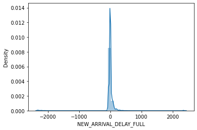

```python
sns.distplot(flights_df_copy['NEW_ARRIVAL_DELAY_FULL'], bins =50)
```

We see a very tall distribution, but with large outliers as well. This is very Leptokurtic, meaning the vast majority of our delays are near 0, but certainly skewed into the negative, meaning they arrived early on average

```python
flights_df_copy['NEW_ARRIVAL_DELAY_FULL'].describe()
```

```
count    5.726566e+06
mean    -1.677204e+01
std      2.721035e+02
min     -2.358000e+03
25%     -1.600000e+01
50%     -6.000000e+00
75%      8.000000e+00
max      2.399000e+03
Name: NEW_ARRIVAL_DELAY_FULL, dtype: float64
```

```python
avg_delay_by_airport = flights_df_copy.groupby('ORIGIN_AIRPORT')['NEW_ARRIVAL_DELAY_FULL'].mean()
```

```python
print(avg_delay_by_airport)
```

```
ORIGIN_AIRPORT
10135     1.584071
10136   -10.406593
10140    -4.525205
10141    -2.424242
10146   -10.548780
           ...
WRG       0.106317
WYS     -12.442308
XNA      13.587803
YAK     -11.170769
YUM       6.067961
Name: NEW_ARRIVAL_DELAY_FULL, Length: 929, dtype: float64
```

Not sure what the integers are doing in our `ORIGIN_AIRPORT` column. Lets go into one?